# Test qPCR

Anze Godicelj

28/03/2018

First, lets set up a neat 384-well (24X16) plate layout and obtain a vector ordered by columns.

```r
#Setting up the order of wells
library(reshape2)
rows <- LETTERS[1:16]
columns <- 1:24
samples <- matrix(ncol= length(columns), nrow = length(rows), NA)
colnames(samples) <- columns
rownames(samples) <- rows
pre_neat <- paste0(melt(samples)$Var1, melt(samples)$Var2)
neat <- rep(pre_neat, each = 2)
neat_2 <- paste(neat,rep(c("JOE","FAM"), times = 384), sep = "_")
```

Next, we need to sort the samples according to the ordered vector and name the samples.

```r
#Loading the data and choosing the relevant columns. (We could just split this matrix into 2 - FAM and JOE. This would bypass the Well_dye merging.)
pre_raw <- as.data.frame(read.csv("~/Dropbox/PIAS3 immunology/2018-03-23 PKG-mPIAS3-qPCR.csv"))[1:192,]
raw <- cbind(as.vector(pre_raw$Well.Position), as.vector(pre_raw$Target.Name), as.vector(pre_raw$CT))
# Because we have duplicates of wells (2 different dyes per well) we need to add the dye classifier to be able to sort the wells.
raw <- cbind(raw,rep(NA, times = nrow(raw)))
raw[raw[,2]%in%"MmACTB",4] <- "JOE"
raw[raw[,2]%in%"mPIAS3",4] <- "FAM"
raw[raw[,2]%in%"18S",4]  <- "JOE"
raw[raw[,2]%in%"hPIAS3",4]  <- "FAM"
raw <- cbind(raw, paste(raw[,1], raw[,4], sep = "_"))

#Sort the table based on the ordered vector.
ordered <- raw[match(neat_2,raw[,5]),]
#Only pick complete cases and remove the last column, because it adds nothing.
pre_clean <- ordered[complete.cases(ordered),-5]
colnames(pre_clean) <- c("Well", "Target", "CT", "Dye")

#Naming the samples
sample_ID <- rep(c(rep("EMT6_WT", times = 8),
                   rep("EMT6_MmPias3_low", times = 8),
                   rep("EMT6_MmPias3_high", times = 8),
                   rep("EMT6_WT_noRT", times = 8),
                   rep("EMT6_MmPias3_low_noRT", times = 8),
                   rep("EMT6_MmPias3_high_noRT", times = 8)), times = 2)

clean <- cbind(sample_ID, pre_clean)
```

We end up with a table that contains both PIAS3 Ct values and housekeeping (ACTB/18S) Ct values. It will be easier if we sepparate these into two different tables.

```r
#Extracting MmPias3/HsPIAS3 Ct values
target <- clean[grep("FAM", clean[,5]),]

#Extracting MmACTB/18S Ct values
control <- clean[grep("JOE", clean[,5]),]
```

Now we are ready to tackle the expression of MmPias3. This will be calculated in two steps: (a) Calculate the difference in MmPias3 Ct values between experimental samples and the average of control (WT) samples. This will give Delta Ct of MmPias3. (b) Calculate the difference in MmACTB Ct values between experimental samples and the average of control (WT) samples. This will give Delta Ct of MmACTB.

First, we need to calculate the difference in expression of MmPias3.

```r
#Pick only first column (others samples will be normalised on a different gene).
MmPIAS3_target <- target[grep("1",target[grep("mPIAS3", target[,3]),2]),]
#E1 is clearly an outlier, so we can remove it.
MmPIAS3_target <- MmPIAS3_target[-3,]

#Create a new matrix. We will need space for Average Control MmPIAS3 Ct value and MmPias3_delta(Ct) value
delta_MmPias3 <- matrix(ncol = ncol(MmPIAS3_target)+2, nrow = nrow(MmPIAS3_target))
colnames(delta_MmPias3) <- c(colnames(MmPIAS3_target), "Average_control_MmPIAS3_Ct", "MmPias3_delta(Ct)")
delta_MmPias3[,1:5] <- MmPIAS3_target

#Calculating the average control MmPias3 Ct value
delta_MmPias3[,6] <- rep(mean(as.numeric(delta_MmPias3[grep("WT", delta_MmPias3[,1]),4])), times = nrow(delta_MmPias3))
#Calculating the delta MmPias3 Ct values
delta_MmPias3[,7] <- as.numeric(delta_MmPias3[,4]) - as.numeric(delta_MmPias3[,6])
```

Now we do the similar analysis for MmACTB.

```r
#Pick only first column.
MmACTB_control <- control[grep("1",control[grep("MmACTB",control[,3]),2]),]

#E1 is clearly an outlier, so we can remove it.
MmACTB_control <- MmACTB_control[-3,]

#Create a new matrix. We will need space for Average Control MmACTB Ct value and MmACTB_delta(Ct) value
delta_MmACTB <- matrix(ncol = ncol(MmACTB_control)+2, nrow = nrow(MmACTB_control))
colnames(delta_MmACTB) <- c(colnames(MmACTB_control), "Average_control_MmACTB_Ct", "MmACTB_delta(Ct)")
delta_MmACTB[,1:5] <- MmACTB_control

#Calculating the average control MmACTB Ct value
delta_MmACTB[,6] <- rep(mean(as.numeric(delta_MmACTB[grep("WT", delta_MmACTB[,1]),4])), times = nrow(delta_MmACTB))
#Calculating the delta MmACTB Ct values
delta_MmACTB[,7] <- as.numeric(delta_MmACTB[,4]) - as.numeric(delta_MmACTB[,6])
```

Now we can calculte the difference between MmPias3_delta(Ct) and MmACTB_delta(Ct).

```r
Delta_delta_MmPias3 <- matrix(ncol = 5, nrow = nrow(delta_MmACTB))
colnames(Delta_delta_MmPias3) <- c("sample_ID","MmPias3_delta(Ct)", "MmACTB_delta(Ct)", "MmPias3_delta(Ct) - MmACTB_delta(Ct)", "log(2)FC" )

Delta_delta_MmPias3[,1] <- delta_MmACTB[,1]
Delta_delta_MmPias3[,2] <- delta_MmPias3[,7]
Delta_delta_MmPias3[,3] <- delta_MmACTB[,7]

#Calculating delta(delta(Ct))
Delta_delta_MmPias3[,4] <- as.numeric(Delta_delta_MmPias3[,2]) - as.numeric(Delta_delta_MmPias3[,3])
#Calculating Log(2)FC
Delta_delta_MmPias3[,5] <- 2^(-(as.numeric(Delta_delta_MmPias3[,4])))
```

Lets plot the results in a boxplot.

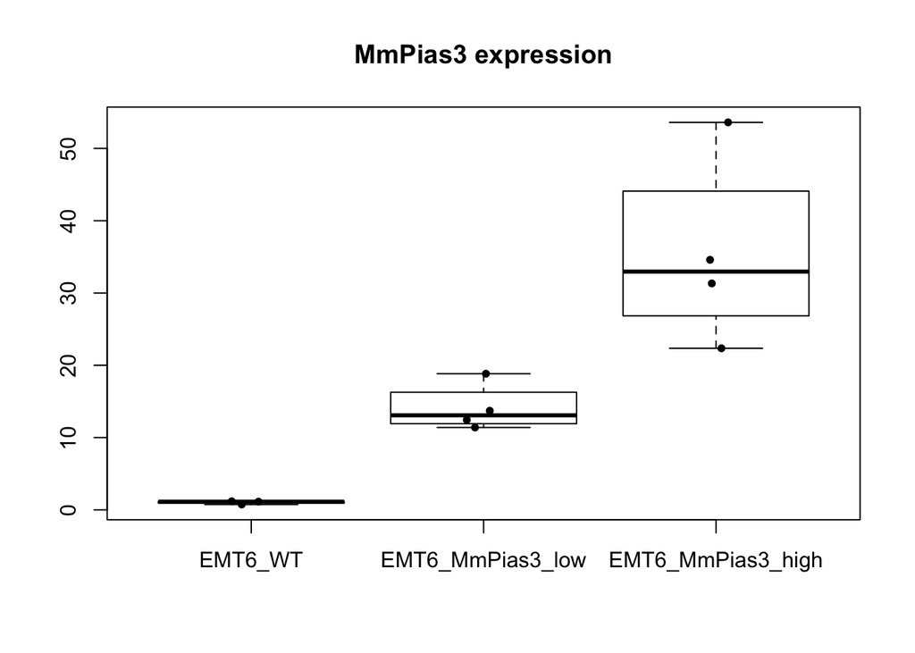

```r
input <- matrix(ncol = 3, nrow = 4)
colnames(input) <- unique(Delta_delta_MmPias3[,1])

input[,1] <- as.numeric(c(Delta_delta_MmPias3[grep("WT", Delta_delta_MmPias3[,1]),5], NA)) # Can I solve this more elegantly??
input[,2] <- as.numeric(Delta_delta_MmPias3[grep("low", Delta_delta_MmPias3[,1]),5])
input[,3] <- as.numeric(Delta_delta_MmPias3[grep("high", Delta_delta_MmPias3[,1]),5])

colnames(input) <- unique(Delta_delta_MmPias3[,1])

boxplot(as.matrix(input), na.rm=TRUE, main = "MmPias3 expression")
stripchart(input[,1], at = 1, vertical = TRUE, method = "jitter", add = TRUE, pch = 20)
stripchart(input[,2], at = 2, vertical = TRUE, method = "jitter", add = TRUE, pch = 20)
stripchart(input[,3], at = 3, vertical = TRUE, method = "jitter", add = TRUE, pch = 20)
```

```r
t.test(input[,1], input[,2], na.rm = TRUE)
```

```
##
##  Welch Two Sample t-test
##
## data:  input[, 1] and input[, 2]
## t = -7.9048, df = 3.0438, p-value = 0.004005
## alternative hypothesis: true difference in means is not equal to 0
## 95 percent confidence interval:
##  -18.29895  -7.85477
## sample estimates:
## mean of x mean of y
##  1.021593 14.098453
```

```r
t.test(input[,1], input[,3], na.rm = TRUE)
```

```
##
##  Welch Two Sample t-test
##
## data:  input[, 1] and input[, 3]
## t = -5.2371, df = 3.0028, p-value = 0.01352
## alternative hypothesis: true difference in means is not equal to 0
## 95 percent confidence interval:
##  -55.36971 -13.52540
## sample estimates:
## mean of x mean of y
##  1.021593 35.469149
```

```r
t.test(input[,2], input[,3], na.rm = TRUE)
```

```
##
##  Welch Two Sample t-test
##
## data:  input[, 2] and input[, 3]
## t = -3.1522, df = 3.3755, p-value = 0.04354
## alternative hypothesis: true difference in means is not equal to 0
## 95 percent confidence interval:
##  -41.650163  -1.091229
## sample estimates:
## mean of x mean of y
##  14.09845  35.46915
```

This analysis can be repeated, but instead of using MmACTB for normalisation, we can use 18S rRNA.

Let’s start with calculating delta Ct for MmPIAS3.

```r
#Pick only third column (others samples will be normalised on a different gene).
MmPIAS3_target <- target[grep("3",target[grep("mPIAS3", target[,3]),2]),]

#D3 is clearly an outlier in 18S expression, so we can remove it.
MmPIAS3_target <- MmPIAS3_target[-2,]


#Create a new matrix. We will need space for Average Control MmPIAS3 Ct value and MmPias3_delta(Ct) value
delta_MmPias3 <- matrix(ncol = ncol(MmPIAS3_target)+2, nrow = nrow(MmPIAS3_target))
colnames(delta_MmPias3) <- c(colnames(MmPIAS3_target), "Average_control_MmPIAS3_Ct", "MmPias3_delta(Ct)")
delta_MmPias3[,1:5] <- MmPIAS3_target

#Calculating the average control MmPias3 Ct value
delta_MmPias3[,6] <- rep(mean(as.numeric(delta_MmPias3[grep("WT", delta_MmPias3[,1]),4])), times = nrow(delta_MmPias3))
#Calculating the delta MmPias3 Ct values
delta_MmPias3[,7] <- as.numeric(delta_MmPias3[,4]) - as.numeric(delta_MmPias3[,6])
```

Now we calculate delta Ct for 18S rRNA.

```r
#Pick only third column.
rRNA_control <- control[grep("3",control[,2]),]

#D3 is clearly an outlier in 18S expression, so we can remove it.
rRNA_control <- rRNA_control[-2,]

#Create a new matrix. We will need space for Average Control rRNA Ct value and rRNA_delta(Ct) value
delta_rRNA <- matrix(ncol = ncol(rRNA_control)+2, nrow = nrow(rRNA_control))
colnames(delta_rRNA) <- c(colnames(rRNA_control), "Average_control_rRNA_Ct", "rRNA_delta(Ct)")
delta_rRNA[,1:5] <- rRNA_control

#Calculating the average control rRNA Ct value
delta_rRNA[,6] <- rep(mean(as.numeric(delta_rRNA[grep("WT", delta_rRNA[,1]),4])), times = nrow(delta_rRNA))
#Calculating the delta rRNA Ct values
delta_rRNA[,7] <- as.numeric(delta_rRNA[,4]) - as.numeric(delta_rRNA[,6])
```

Finally, we can calculate the difference between MmPias3_delta(Ct) and rRNA_delta(Ct)

```r
Delta_delta_MmPias3 <- matrix(ncol = 5, nrow = nrow(delta_rRNA))
colnames(Delta_delta_MmPias3) <- c("sample_ID","MmPias3_delta(Ct)", "rRNA_delta(Ct)", "MmPias3_delta(Ct) - rRNA_delta(Ct)", "log(2)FC" )

Delta_delta_MmPias3[,1] <- delta_rRNA[,1]
Delta_delta_MmPias3[,2] <- delta_MmPias3[,7]
Delta_delta_MmPias3[,3] <- delta_rRNA[,7]

#Calculating delta(delta(Ct))
Delta_delta_MmPias3[,4] <- as.numeric(Delta_delta_MmPias3[,2]) - as.numeric(Delta_delta_MmPias3[,3])
#Calculating Log(2)FC
Delta_delta_MmPias3[,5] <- 2^(-(as.numeric(Delta_delta_MmPias3[,4])))
```

To finish, we can plot the data with a boxplot.

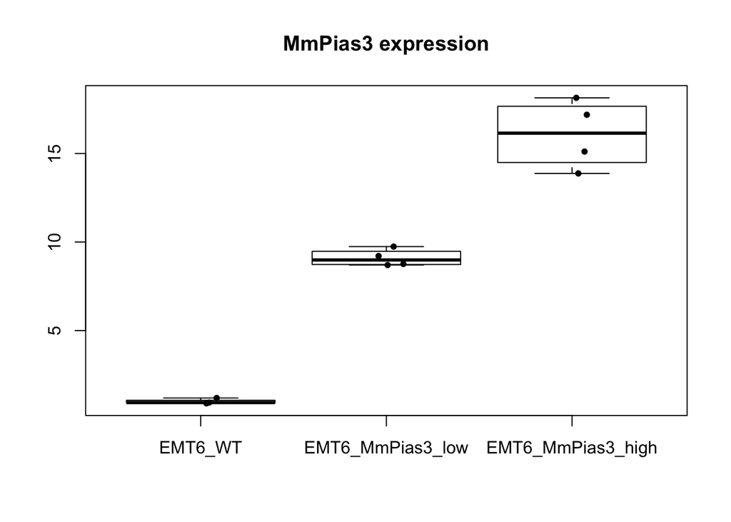

```r
input <- matrix(ncol = 3, nrow = 4)
colnames(input) <- unique(Delta_delta_MmPias3[,1])

input[,1] <- as.numeric(c(Delta_delta_MmPias3[grep("WT", Delta_delta_MmPias3[,1]),5], NA)) # Can I solve this more elegantly??
input[,2] <- as.numeric(Delta_delta_MmPias3[grep("low", Delta_delta_MmPias3[,1]),5])
input[,3] <- as.numeric(Delta_delta_MmPias3[grep("high", Delta_delta_MmPias3[,1]),5])

colnames(input) <- unique(Delta_delta_MmPias3[,1])

boxplot(as.matrix(input), na.rm=TRUE, main = "MmPias3 expression")
stripchart(input[,1], at = 1, vertical = TRUE, method = "jitter", add = TRUE, pch = 20)
stripchart(input[,2], at = 2, vertical = TRUE, method = "jitter", add = TRUE, pch = 20)
stripchart(input[,3], at = 3, vertical = TRUE, method = "jitter", add = TRUE, pch = 20)
```

```r
t.test(input[,1], input[,2], na.rm = TRUE)
```

```
##
##  Welch Two Sample t-test
##
## data:  input[, 1] and input[, 2]
## t = -31.307, df = 3.8386, p-value = 9.104e-06
## alternative hypothesis: true difference in means is not equal to 0
## 95 percent confidence interval:
##  -8.826345 -7.366191
## sample estimates:
## mean of x mean of y
##  1.008228  9.104496
```

```r
t.test(input[,1], input[,3], na.rm = TRUE)
```

```
##
##  Welch Two Sample t-test
##
## data:  input[, 1] and input[, 3]
## t = -15.464, df = 3.0555, p-value = 0.0005306
## alternative hypothesis: true difference in means is not equal to 0
## 95 percent confidence interval:
##  -18.14005 -12.00055
## sample estimates:
## mean of x mean of y
##  1.008228 16.078530
```

```r
t.test(input[,2], input[,3], na.rm = TRUE)
```

```
##
##  Welch Two Sample t-test
##
## data:  input[, 2] and input[, 3]
## t = -6.9771, df = 3.3694, p-value = 0.004098
## alternative hypothesis: true difference in means is not equal to 0
## 95 percent confidence interval:
##  -9.966629 -3.981439
## sample estimates:
## mean of x mean of y
##  9.104496 16.078530
```